# Survival Gene Discovery Pipeline

## TCGA Pancreatic Adenocarcinoma (PAAD)

## Overview

This repository demonstrate the script for reproducible survival analysis pipeline using RNA-seq data from TCGA Pancreatic Adenocarcinoma (PAAD). The goal is to identify prognostic genes, construct a prognostic risk stratification model and evaluate its predictive performance using survival statistics and ROC analysis. Here I have not used the validation cohorts and have just included the survival pipeline using TCGA (as training dataset) and the code to generate common plots so that anyone can replicate it using TCGA data.

The workflow includes:

- Data acquisition from TCGA
- Preprocessing and normalization
- Survival modeling (univariate + multivariate Cox regression)
- Feature selection using LASSO regression
- Prognostic Risk score model construction
- Model evaluation (Kaplan–Meier + ROC) curves

## Required Packages

We will use several Bioconductor and CRAN packages for genomic data processing, survival analysis, and visualization.

```r
#Load Packages
library(TCGAbiolinks)
library(SummarizedExperiment)
library(DESeq2)
library(survival)
library(dplyr)
library(tibble)
library(glmnet)
library(survminer)
library(timeROC)
```

## Step 1–3: Data Acquisition and Expression Matrix Preparation

We retrieve the TCGA-PAAD data from the GDC (Genomic Data Commons) portal using TCGAbiolinks R package. We need to:

1. Query for the correct dataset (TCGA-PAAD pancreatic cancer)
2. Download raw counts (not normalized data)
3. Extract counts and gene annotations and remove the genes without valid names and duplicate gene entries

Here data is a SummarizedExperiment object containing:

- assay(data) = count matrix (genes × samples)
- rowData(data) = gene annotations
- colData(data) = sample metadata

```r
# STEP 1-3: Download and Extract Expression Data

query <- GDCquery(
  project = "TCGA-PAAD",                        # Pancreatic Adenocarcinoma
  data.category = "Transcriptome Profiling",    # Gene expression data
  experimental.strategy = "RNA-Seq",            # RNA-seq (not microarray)
  workflow.type = "STAR - Counts",              # STAR aligner, raw counts
  data.type = "Gene Expression Quantification", # Expression data type
  sample.type = "Primary Tumor"                 # Only primary tumors (not metastatic)
)
```

```r
# Extract counts and annotations
counts_raw <- assay(data) # Extract count matrix
gene_info <- rowData(data)# Extract gene annotations

# Keep only genes with valid names (not unknown/unmapped)
valid_genes <- !is.na(gene_info$gene_name) & gene_info$gene_name != ""
counts_raw <- counts_raw[valid_genes, ]
gene_info <- gene_info[valid_genes, ]
head(gene_info)
```

```
## DataFrame with 6 rows and 10 columns
##                      source     type     score     phase            gene_id
##                    <factor> <factor> <numeric> <integer>        <character>
## ENSG00000000003.15   HAVANA     gene        NA        NA ENSG00000000003.15
## ENSG00000000005.6    HAVANA     gene        NA        NA  ENSG00000000005.6
## ENSG00000000419.13   HAVANA     gene        NA        NA ENSG00000000419.13
## ENSG00000000457.14   HAVANA     gene        NA        NA ENSG00000000457.14
## ENSG00000000460.17   HAVANA     gene        NA        NA ENSG00000000460.17
## ENSG00000000938.13   HAVANA     gene        NA        NA ENSG00000000938.13
##                         gene_type   gene_name       level     hgnc_id
##                       <character> <character> <character> <character>
## ENSG00000000003.15 protein_coding      TSPAN6           2  HGNC:11858
## ENSG00000000005.6  protein_coding        TNMD           2  HGNC:17757
## ENSG00000000419.13 protein_coding        DPM1           2   HGNC:3005
## ENSG00000000457.14 protein_coding       SCYL3           2  HGNC:19285
## ENSG00000000460.17 protein_coding    C1orf112           2  HGNC:25565
## ENSG00000000938.13 protein_coding         FGR           2   HGNC:3697
##                             havana_gene
##                             <character>
## ENSG00000000003.15 OTTHUMG00000022002.2
## ENSG00000000005.6  OTTHUMG00000022001.2
## ENSG00000000419.13 OTTHUMG00000032742.2
## ENSG00000000457.14 OTTHUMG00000035941.6
## ENSG00000000460.17 OTTHUMG00000035821.9
## ENSG00000000938.13 OTTHUMG00000003516.3
```

```r
# Remove duplicates, keep first occurrence
keep_genes <- !duplicated(gene_info$gene_name)
counts_raw <- counts_raw[keep_genes, ]
gene_info <- gene_info[keep_genes, ]

rownames(counts_raw) <- gene_info$gene_name
dim(counts_raw) # number of genes in the dataset
```

```
## [1] 59427   178
```

```r
head(counts_raw[, 1:4]) #gene names updated in the data frame
```

```
##          TCGA-HZ-A8P1-01A-11R-A37L-07 TCGA-FB-AAPS-01A-12R-A39D-07
## TSPAN6                           1013                         1175
## TNMD                                1                           54
## DPM1                             1143                          877
## SCYL3                            1089                          371
## C1orf112                          221                          106
## FGR                               216                          769
##          TCGA-IB-AAUN-01A-12R-A38C-07 TCGA-3A-A9I7-01A-21R-A38C-07
## TSPAN6                           1658                         1790
## TNMD                                2                            0
## DPM1                             1538                         1345
## SCYL3                             528                          733
## C1orf112                          190                          204
## FGR                               499                          492
```

## Step 4: Clinical Data Processing

Expression data and clinical data are stored separately in GDC. We need to retrieve clinical metadata to extract survival information (time to death, event status).

- Overall Survival Time (OS_time)
  - Death time (if patient is deceased)
  - Last follow-up time (if alive)
- Event Indicator (OS_event):
  - 1 = death
  - 0 = censored

We filter:

- Missing survival times
- Non-positive follow-up values

```r
# STEP 4: Download Clinical Data
clinical <- GDCquery_clinic("TCGA-PAAD", type = "clinical")

# Create survival variables with proper validation
clinical <- clinical %>%
  mutate(
    OS_time = case_when(
      !is.na(days_to_death) ~ days_to_death,  # Dead patients: use actual death time
      !is.na(days_to_last_follow_up) & days_to_last_follow_up > 0 ~ days_to_last_follow_up,  # Alive: use follow-up time
      TRUE ~ NA_real_        # Missing both: mark as NA
    ),
    OS_event = case_when(
      vital_status == "Dead" ~ 1,  # 1 = event occurred (death)
      vital_status == "Alive" ~ 0, # 0 = censored (still alive)
      TRUE ~ NA_integer_           # Unknown: NA
    )
  ) %>%
  filter(!is.na(OS_time) & OS_time > 0 & !is.na(OS_event))   # Keep only valid cases
head(clinical[, 1:4])
```

```
##     project submitter_id synchronous_malignancy tumor_grade_category
## 1 TCGA-PAAD TCGA-3A-A9IS                     No            Four Tier
## 2 TCGA-PAAD TCGA-2L-AAQM                     No           Three Tier
## 3 TCGA-PAAD TCGA-3A-A9IO                     No            Four Tier
## 4 TCGA-PAAD TCGA-US-A77J                     No            Four Tier
## 5 TCGA-PAAD TCGA-3A-A9IV                     No            Four Tier
## 6 TCGA-PAAD TCGA-3A-A9IR                     No            Four Tier
```

## Step 5: Handling Duplicate Samples

TCGA often has multiple samples per patient (repeated measurements). To avoid bias we extract patient IDs from sample barcodes and retain only one sample per patient (first occurrence). This will make sure independent observation and correct survival modeling assumptions.

```r
# STEP 5: Handle Duplicate Samples
patients <- substr(colnames(counts_raw), 1, 12) # Extract first 12 chars = patient ID

sample_info <- data.frame(
  sample_barcode = colnames(counts_raw),
  patient_id = patients,
  stringsAsFactors = FALSE
)

# Keep one sample per patient (first replicate)
sample_info_unique <- sample_info %>%
  group_by(patient_id) %>%
  slice(1) %>%      # Keep only FIRST sample per patient
  ungroup()

counts <- counts_raw[, sample_info_unique$sample_barcode]
patients_final <- sample_info_unique$patient_id
```

## Step 6: Normalization

Raw RNA-seq counts are normalized using DESeq2’s Variance Stabilizing Transformation (VST) function.

VST transforms counts so that:

- Library size normalized (accounts for size factors)
- Stabilizes variance across expression levels
- Makes data approximately normally distributed (suitable for linear models and cox regression)

```r
# STEP 6: Normalization (DESeq2 - VST)
dds <- DESeqDataSetFromMatrix(
  countData = counts,
  colData = data.frame(row.names = colnames(counts)),
  design = ~1
)

dds <- estimateSizeFactors(dds)
vsd <- vst(dds)
expr_vst <- assay(vsd)
head(expr_vst[, 1:4])
```

```
##          TCGA-2J-AAB1-01A-11R-A41B-07 TCGA-2J-AAB4-01A-12R-A41B-07
## TSPAN6                      10.382122                    10.758464
## TNMD                         2.444444                     2.444444
## DPM1                        10.015933                    10.097949
## SCYL3                        9.533962                     9.262617
## C1orf112                     7.667816                     7.509966
## FGR                         10.021632                     9.481382
##          TCGA-2J-AAB6-01A-11R-A41B-07 TCGA-2J-AAB8-01A-12R-A41B-07
## TSPAN6                      10.544528                    10.320626
## TNMD                         2.444444                     4.216337
## DPM1                        11.371518                    10.431606
## SCYL3                        8.793815                    10.049105
## C1orf112                     8.888737                     8.352536
## FGR                          8.958897                     9.122676
```

## Step 7: Filtering Low-Expression Genes

We will filter low-expression genes as low expression genes are noisy, and reduces multiple testing burden and dimensionality.

```r
# STEP 7: Filter Low-Expression Genes
keep <- rowMeans(expr_vst) > 5
expr_filtered_pre_z <- expr_vst[keep, ]
dim(expr_filtered_pre_z)
```

```
## [1] 17720   178
```

## Step 8: Z-score Standardization

Gene expression is standardized across samples i-e Mean = 0 and standard deviation = 1. The standardization will ensure comparability across genes especially for Cox regression that works with standardized coefficients.

```r
# STEP 8: Z-Score Standardization (on filtered genes)
expr_z <- t(scale(t(expr_filtered_pre_z)))
head(expr_z[, 1:4])
```

```
##          TCGA-2J-AAB1-01A-11R-A41B-07 TCGA-2J-AAB4-01A-12R-A41B-07
## TSPAN6                     -0.3373355                   0.12786371
## DPM1                       -1.0863194                  -0.87032888
## SCYL3                       0.2167432                  -0.37562992
## C1orf112                   -0.1320077                  -0.43631296
## FGR                         0.6038313                   0.11045863
## CFH                         0.1194155                   0.02138082
##          TCGA-2J-AAB6-01A-11R-A41B-07 TCGA-2J-AAB8-01A-12R-A41B-07
## TSPAN6                     -0.1365838                 -0.413351981
## DPM1                        2.4836392                  0.008363336
## SCYL3                      -1.3990712                  1.341352049
## C1orf112                    2.2217110                  1.188011179
## FGR                        -0.3666899                 -0.217122287
## CFH                        -0.3132656                 -0.243542617
```

## Step 9: Merging Expression with Clinical Data

We merge expression data with clinical survival data, matching by patient ID and ensuring alignment between datasets so that we get the final dataset with one row per patient with gene expression values, survival event and survival time.

```r
# STEP 9: Merge Expression with Clinical Data
expr_surv_df <- as.data.frame(t(expr_z))
rownames(expr_surv_df) <- patients_final

expr_surv_df <- expr_surv_df %>%
  rownames_to_column(var = "patient_id")

data_surv <- inner_join(
  expr_surv_df,
  clinical %>% select(submitter_id, OS_time, OS_event),
  by = c("patient_id" = "submitter_id")
)

rownames(data_surv) <- data_surv$patient_id   #after merging set row names to patient IDs.

# CRITICAL: Extract first 12 characters from expr_z column names (patient IDs)
colnames(expr_z) <- substr(colnames(expr_z), 1, 12)

# Align expr_z with data_surv by sub-setting to matching patients
patients_in_surv <- rownames(data_surv)
expr_z <- expr_z[, patients_in_surv]

head(data_surv[,c(1:3,17721,17722,17723)]) #clinical data merged with expression data.
```

```
##                patient_id     TSPAN6         DPM1  AP006621.6 OS_time OS_event
## TCGA-2J-AAB1 TCGA-2J-AAB1 -0.3373355 -1.086319397  0.70561909      66        1
## TCGA-2J-AAB4 TCGA-2J-AAB4  0.1278637 -0.870328879 -0.78730650     729        0
## TCGA-2J-AAB6 TCGA-2J-AAB6 -0.1365838  2.483639228  0.05950069     293        1
## TCGA-2J-AAB8 TCGA-2J-AAB8 -0.4133520  0.008363336  0.39150902      80        0
## TCGA-2J-AAB9 TCGA-2J-AAB9  0.5568173  0.333379210  0.23026833     627        1
## TCGA-2J-AABA TCGA-2J-AABA  0.6050069 -0.529255675 -0.22446614     607        1
```

## Step 10: Univariate Cox Regression (all genes)

In this step we will test each gene independently to identify which genes are associated with survival. We perform a gene wise cox regression for each gene to estimate their Hazard Ratio (HR), compute the 95% Confidence Interval and p-value.

```r
#Step 10: Univariate regression
n_genes <- nrow(expr_z)

results <- data.frame(
  gene = rownames(expr_z),
  HR = numeric(n_genes),
  HR_lower = numeric(n_genes),
  HR_upper = numeric(n_genes),
  pvalue = numeric(n_genes),
  convergence = logical(n_genes),
  stringsAsFactors = FALSE
)

for (i in seq_len(n_genes)) {
  gene <- rownames(expr_z)[i]

  tryCatch({
    # Create the survival object and fit cox model directly
    y <- Surv(data_surv$OS_time, data_surv$OS_event)
    x <- data_surv[[gene]]

    model <- coxph(y ~ x)

    # FIX: Check if model has coefficients (instead of checking $convergence)
    if (is.na(coef(model)[1]) || length(coef(model)) == 0) {
      results$convergence[i] <- FALSE
      next
    }

    summary_model <- summary(model)

    # Extract results (coefficient name is just "x")
    results$HR[i] <- summary_model$coefficients["x", "exp(coef)"]
    results$HR_lower[i] <- summary_model$conf.int["x", "lower .95"]
    results$HR_upper[i] <- summary_model$conf.int["x", "upper .95"]
    results$pvalue[i] <- summary_model$coefficients["x", "Pr(>|z|)"]
    results$convergence[i] <- TRUE

  }, error = function(e) {
    results$convergence[i] <<- FALSE
  })

  if (i %% 5000 == 0) {
    print(paste("Processed", i, "/", n_genes, "genes"))
  }
}
```

```
## [1] "Processed 5000 / 17720 genes"
## [1] "Processed 10000 / 17720 genes"
## [1] "Processed 15000 / 17720 genes"
```

```r
results <- results[results$convergence, ]

print(paste("Total genes with valid results:", nrow(results)))
```

```
## [1] "Total genes with valid results: 17720"
```

```r
print(paste("Genes with convergence issues:", n_genes - nrow(results)))
```

```
## [1] "Genes with convergence issues: 0"
```

```r
if (nrow(results) > 0) {
  print("Top 10 genes by p-value:")
  print(head(results %>% arrange(pvalue), 10))
} else {
  print("No genes converged!")
}
```

```
## [1] "Top 10 genes by p-value:"
##      gene        HR  HR_lower  HR_upper       pvalue convergence
## 1     MET 2.2048359 1.6733244 2.9051757 1.932692e-08        TRUE
## 2  INSIG2 1.7481766 1.4331821 2.1324026 3.580284e-08        TRUE
## 3  ARNTL2 1.7068019 1.4053513 2.0729141 6.969856e-08        TRUE
## 4  ACTL6A 1.8793853 1.4925838 2.3664259 8.029068e-08        TRUE
## 5    LY6D 1.7846069 1.4370920 2.2161572 1.591901e-07        TRUE
## 6   USP20 0.4899948 0.3744579 0.6411800 2.000841e-07        TRUE
## 7   KPNA4 1.7654721 1.4219604 2.1919681 2.623321e-07        TRUE
## 8  PDCD10 1.8609021 1.4672439 2.3601779 3.031001e-07        TRUE
## 9    TLE2 0.5797816 0.4702559 0.7148167 3.347731e-07        TRUE
## 10 FAM83A 1.7753263 1.4233560 2.2143325 3.557851e-07        TRUE
```

## Step 11: Multiple Testing Correction

Since we performed thousands of tests so to control false positives results we use Benjamini–Hochberg false discovery correction using FDR < 0.01 as statically significant genes. We classify genes as risk genes where HR > 1 and protective genes where HR < 1.

```r
# STEP 11: Multiple Testing Correction (FDR) and Filtering
results$FDR <- p.adjust(results$pvalue, method = "BH")

# Use FDR < 0.05 or 0.01
significant_genes <- results %>%
  filter(FDR < 0.01) %>%
  mutate(log2_HR = log2(HR)) %>%
  arrange(FDR)

print(paste("Genes with FDR < 0.01:", nrow(significant_genes)))
```

```
## [1] "Genes with FDR < 0.01: 1964"
```

```r
significant_genes$log2_HR <- log2(significant_genes$HR)

print("\nTop 15 genes by FDR:")
```

```
## [1] "\nTop 15 genes by FDR:"
```

```r
print(head(significant_genes, 15))
```

```
##       gene        HR  HR_lower  HR_upper       pvalue convergence          FDR
## 1      MET 2.2048359 1.6733244 2.9051757 1.932692e-08        TRUE 0.0003172131
## 2   INSIG2 1.7481766 1.4331821 2.1324026 3.580284e-08        TRUE 0.0003172131
## 3   ARNTL2 1.7068019 1.4053513 2.0729141 6.969856e-08        TRUE 0.0003556877
## 4   ACTL6A 1.8793853 1.4925838 2.3664259 8.029068e-08        TRUE 0.0003556877
## 5     LY6D 1.7846069 1.4370920 2.2161572 1.591901e-07        TRUE 0.0005641696
## 6    USP20 0.4899948 0.3744579 0.6411800 2.000841e-07        TRUE 0.0005909150
## 7     TLE2 0.5797816 0.4702559 0.7148167 3.347731e-07        TRUE 0.0006304512
## 8   PDCD10 1.8609021 1.4672439 2.3601779 3.031001e-07        TRUE 0.0006304512
## 9   FAM83A 1.7753263 1.4233560 2.2143325 3.557851e-07        TRUE 0.0006304512
## 10   KPNA4 1.7654721 1.4219604 2.1919681 2.623321e-07        TRUE 0.0006304512
## 11    ANLN 1.8981326 1.4732838 2.4454944 7.145254e-07        TRUE 0.0006360203
## 12   LAMA3 1.8430493 1.4411006 2.3571085 1.109698e-06        TRUE 0.0006360203
## 13 SEC61A2 0.5707580 0.4550750 0.7158484 1.218549e-06        TRUE 0.0006360203
## 14    CDK6 1.8083614 1.4374163 2.2750339 4.242621e-07        TRUE 0.0006360203
```

[output cut: 17 more lines]

## Step 12: Proportional Hazards Assumption Testing

The cox model assumes that hazard ratio are constant over time. We test this using Schoenfeld residuals (cox.zph). The genes violating this assumption will be removed from further analysis to make sure valid interpretation of cox results and model reliability.

```r
# STEP 12: Test Proportional Hazards Assumption
# Create a smaller dataset with only significant genes
data_cox <- data_surv %>%
  select(OS_time, OS_event, all_of(significant_genes$gene))

# Fit univariate Cox models for each gene and test PH assumption
ph_test_results <- data.frame(
  gene = significant_genes$gene,
  ph_test_pvalue = numeric(nrow(significant_genes)),
  ph_violated = logical(nrow(significant_genes))
)

for (i in seq_len(nrow(significant_genes))) {
  gene <- significant_genes$gene[i]

  y <- Surv(data_cox$OS_time, data_cox$OS_event)
  x <- data_cox[[gene]]

  model <- coxph(y ~ x)
  ph_test <- cox.zph(model)

  ph_test_results$ph_test_pvalue[i] <- ph_test$table[1, 3]
  ph_test_results$ph_violated[i] <- ph_test$table[1, 3] < 0.05
}

print(paste("Genes violating PH assumption (p < 0.05):", sum(ph_test_results$ph_violated)))
```

```
## [1] "Genes violating PH assumption (p < 0.05): 36"
```

```r
print(paste("Genes meeting PH assumption:", sum(!ph_test_results$ph_violated)))
```

```
## [1] "Genes meeting PH assumption: 1928"
```

```r
# Filter genes that violate PH assumption
significant_genes_filtered <- significant_genes %>%
  filter(!(gene %in% ph_test_results$gene[ph_test_results$ph_violated]))

print(paste("\nGenes after PH filtering:", nrow(significant_genes_filtered)))
```

```
## [1] "\nGenes after PH filtering: 1928"
```

```r
print(paste("Risk genes:", sum(significant_genes_filtered$HR > 1)))
```

```
## [1] "Risk genes: 1066"
```

```r
print(paste("Protective genes:", sum(significant_genes_filtered$HR < 1)))
```

```
## [1] "Protective genes: 862"
```

```r
# Show genes that were removed
removed_genes <- ph_test_results %>%
  filter(ph_violated) %>%
  arrange(ph_test_pvalue)

if (nrow(removed_genes) > 0) {
  print("\nGenes removed (violating PH assumption):")
  print(head(removed_genes, 10))
}
```

```
## [1] "\nGenes removed (violating PH assumption):"
##          gene ph_test_pvalue ph_violated
## 1  AC008610.1     0.01154876        TRUE
## 2    SEPTIN11     0.01441735        TRUE
## 3        CAP1     0.01698406        TRUE
## 4  AC034236.2     0.01751971        TRUE
## 5     SUZ12P1     0.02053243        TRUE
## 6  ARRDC1-AS1     0.02090659        TRUE
## 7  AC007485.2     0.02273131        TRUE
## 8       SPEF2     0.02467617        TRUE
## 9  DICER1-AS1     0.02495912        TRUE
## 10       EZH1     0.02655159        TRUE
```

## Step 13: LASSO Feature Selection

To reduce dimensionality and avoid overfitting we apply Lasso cox regression (glmnet) to get a reduced set of prognostic genes after univariate regression. Lasso remove less informative variables and perform automatic selection. Here we use a 5-fold cross-validation and lambda.min for optimal selection.

```r
# STEP 13: LASSO Feature Selection

# Prepare data for LASSO
# Use the filtered significant genes that passed PH assumption
X <- as.matrix(data_cox[, significant_genes_filtered$gene])
y <- Surv(data_cox$OS_time, data_cox$OS_event)

# Fit LASSO with cross-validation
set.seed(123)

lasso_model <- cv.glmnet(
  X, y,
  family = "cox",
  alpha = 1,        # pure LASSO penalty
  nfolds = 5        # more stable for ~150 patients
)

# Use lambda.min (less conservative than lambda.1se)
selected_coefs <- coef(lasso_model, s = "lambda.min")

# Extract selected genes (non-zero coefficients)
selected_genes_lasso <- rownames(selected_coefs)[selected_coefs[, 1] != 0]

print(paste("Number of genes selected by LASSO:", length(selected_genes_lasso)))
```

```
## [1] "Number of genes selected by LASSO: 10"
```

```r
print("Genes selected:")
```

```
## [1] "Genes selected:"
```

```r
print(selected_genes_lasso)
```

```
##  [1] "MET"     "INSIG2"  "LY6D"    "USP20"   "SEC61A2" "MRPL3"   "MRPS22"
##  [8] "CASKIN2" "PPP2R3A" "MYEOV"
```

```r
# Get LASSO coefficients for selected genes
lasso_coefs <- as.data.frame(as.matrix(selected_coefs[selected_genes_lasso, ]))
colnames(lasso_coefs) <- "lasso_coef"
lasso_coefs$gene <- rownames(lasso_coefs)

print("\nLASSO Coefficients:")
```

```
## [1] "\nLASSO Coefficients:"
```

```r
print(lasso_coefs %>% arrange(desc(abs(lasso_coef))))
```

```
##           lasso_coef    gene
## MET      0.144615536     MET
## LY6D     0.081465932    LY6D
## USP20   -0.046494087   USP20
## INSIG2   0.038858283  INSIG2
## MRPL3    0.032294663   MRPL3
## PPP2R3A  0.017500118 PPP2R3A
## CASKIN2 -0.014910692 CASKIN2
## SEC61A2 -0.014166436 SEC61A2
## MYEOV    0.010668306   MYEOV
## MRPS22   0.004140807  MRPS22
```

```r
# Update significant genes to only LASSO-selected genes
final_genes <- significant_genes_filtered %>%
  filter(gene %in% selected_genes_lasso)

print(paste("\nFinal gene set size:", nrow(final_genes)))
```

```
## [1] "\nFinal gene set size: 10"
```

## Step 14: Multivariate Cox Regression Model

We construct a multivariate cox regression model using genes selected from Lasso. This help to estimate independent effects and evaluate combine predictive power giving the Hazard ratios, p-values, and concordance index (C-index).

```r
# STEP 14: Fit Multivariate Cox Model
# Use the LASSO-selected genes directly
genes_formula <- paste(paste("`", selected_genes_lasso, "`", sep = ""),
                       collapse = " + ")
formula_multivariate <- as.formula(paste("y ~", genes_formula))

# Fit multivariate Cox model
multivariate_model <- coxph(formula_multivariate, data = data_cox)

# Get summary
summary_multivariate <- summary(multivariate_model)

print(paste("Number of genes in model:", length(selected_genes_lasso)))
```

```
## [1] "Number of genes in model: 10"
```

```r
print(paste("Likelihood ratio test p-value:",
            format(summary_multivariate$sctest[3], scientific = TRUE)))
```

```
## [1] "Likelihood ratio test p-value: 9.603252e-10"
```

```r
print(paste("Concordance index:", round(summary_multivariate$concordance[1], 3)))
```

```
## [1] "Concordance index: 0.749"
```

```r
# Extract coefficients
multivariate_coefs <- as.data.frame(summary_multivariate$coefficients) %>%
  rownames_to_column(var = "gene") %>%
  select(gene, coef, `exp(coef)`, `Pr(>|z|)`)

colnames(multivariate_coefs) <- c("gene", "coef", "HR", "pvalue")
multivariate_coefs <- multivariate_coefs %>% arrange(pvalue)

print("\nMultivariate Cox Coefficients:")
```

```
## [1] "\nMultivariate Cox Coefficients:"
```

```r
print(multivariate_coefs)
```

```
##       gene        coef        HR      pvalue
## 1     LY6D  0.36072289 1.4343659 0.002486739
## 2    MYEOV  0.51477485 1.6732617 0.008920488
## 3  SEC61A2 -0.33255667 0.7170880 0.021213211
## 4  PPP2R3A  0.32150469 1.3792015 0.023881672
## 5  CASKIN2 -0.25478810 0.7750807 0.061904999
## 6    MRPL3  0.20266861 1.2246666 0.251337626
## 7    USP20 -0.20415953 0.8153323 0.289709078
## 8   INSIG2  0.13937696 1.1495574 0.467547877
## 9   MRPS22 -0.01005949 0.9899909 0.952141951
## 10     MET -0.01475370 0.9853546 0.953863996
```

```r
# Save for next step
final_genes_coefs <- multivariate_coefs
```

## Step 15: Risk Score Development

We compute a risk score for each patient. Based on the median cut-off risk score, each patient is stratified into high-risk group and low risk group in the TCGA-PAAD data to evaluate their association with survival. Risk score = ∑ni (expi • coefi) Where n is the number of genes identified in the LASSO Cox regression, expi is the expression value of gene i, and coefi is the coefficient (coef) in the multivariate cox regression for each selected gene.

```r
# STEP 15: Risk Score Development

# Calculate risk score for each patient
# Risk Score = sum of (gene_expression * coefficient)

risk_score <- matrix(0, nrow = nrow(data_cox), ncol = 1)
colnames(risk_score) <- "risk_score"

for (i in seq_len(nrow(multivariate_coefs))) {
  gene <- multivariate_coefs$gene[i]
  coef <- multivariate_coefs$coef[i]

  risk_score <- risk_score + (data_cox[[gene]] * coef)
}

# Add risk score to data
data_cox$risk_score <- risk_score[, 1]

# Categorize patients into risk groups (median split)
risk_cutoff <- median(data_cox$risk_score)
data_cox$risk_group <- ifelse(data_cox$risk_score >= risk_cutoff, "High", "Low")

print(paste("Number of genes in risk score:", nrow(multivariate_coefs)))
```

```
## [1] "Number of genes in risk score: 10"
```

```r
print(paste("Risk score range:", round(min(data_cox$risk_score), 2),
            "to", round(max(data_cox$risk_score), 2)))
```

```
## [1] "Risk score range: -5.75 to 3.37"
```

```r
print(paste("Median risk score:", round(risk_cutoff, 2)))
```

```
## [1] "Median risk score: 0.24"
```

```r
print("\nRisk group distribution:")
```

```
## [1] "\nRisk group distribution:"
```

```r
print(table(data_cox$risk_group))
```

```
##
## High  Low
##   89   88
```

```r
# Fit Cox model with risk score as single predictor
y <- Surv(data_cox$OS_time, data_cox$OS_event)
risk_model <- coxph(y ~ risk_score, data = data_cox)
summary_risk <- summary(risk_model)

print("\nCox Model with Risk Score as Predictor:")
```

```
## [1] "\nCox Model with Risk Score as Predictor:"
```

```r
print(paste("HR per 1 unit increase in risk score:",
            round(summary_risk$coefficients[1, 2], 3)))
```

```
## [1] "HR per 1 unit increase in risk score: 2.718"
```

```r
print(paste("95% CI:",
            round(summary_risk$conf.int[1, 3], 3), "-",
            round(summary_risk$conf.int[1, 4], 3)))
```

```
## [1] "95% CI: 2.122 - 3.482"
```

```r
print(paste("p-value:", format(summary_risk$coefficients[1, 5], scientific = TRUE)))
```

```
## [1] "p-value: 2.455297e-15"
```

```r
print(paste("Concordance index:", round(summary_risk$concordance[1], 3)))
```

```
## [1] "Concordance index: 0.749"
```

```r
# Compare risk groups
risk_model_group <- coxph(y ~ risk_group, data = data_cox)
summary_risk_group <- summary(risk_model_group)

print("\nCox Model Comparing Risk Groups (High vs Low):")
```

```
## [1] "\nCox Model Comparing Risk Groups (High vs Low):"
```

```r
print(paste("HR (High vs Low):", round(summary_risk_group$coefficients[1, 2], 3)))
```

```
## [1] "HR (High vs Low): 0.282"
```

```r
print(paste("95% CI:",
            round(summary_risk_group$conf.int[1, 3], 3), "-",
            round(summary_risk_group$conf.int[1, 4], 3)))
```

```
## [1] "95% CI: 0.179 - 0.444"
```

```r
print(paste("p-value:", format(summary_risk_group$coefficients[1, 5], scientific = TRUE)))
```

```
## [1] "p-value: 4.96465e-08"
```

```r
# Survival statistics by group
high_risk <- data_cox$OS_event[data_cox$risk_group == "High"]
low_risk <- data_cox$OS_event[data_cox$risk_group == "Low"]

print("\nSurvival Events by Risk Group:")
```

```
## [1] "\nSurvival Events by Risk Group:"
```

```r
print(paste("High risk group: ", sum(high_risk), "/", length(high_risk),
            "events (", round(100*mean(high_risk), 1), "%)"))
```

```
## [1] "High risk group:  66 / 89 events ( 74.2 %)"
```

```r
print(paste("Low risk group: ", sum(low_risk), "/", length(low_risk),
            "events (", round(100*mean(low_risk), 1), "%)"))
```

```
## [1] "Low risk group:  27 / 88 events ( 30.7 %)"
```

## Step 16: Kaplan–Meier Survival Analysis

To visualize the survival difference between high and low risk groups we use Kaplan-Meier curve and log-rank test. This provides clinical relevance of the model.

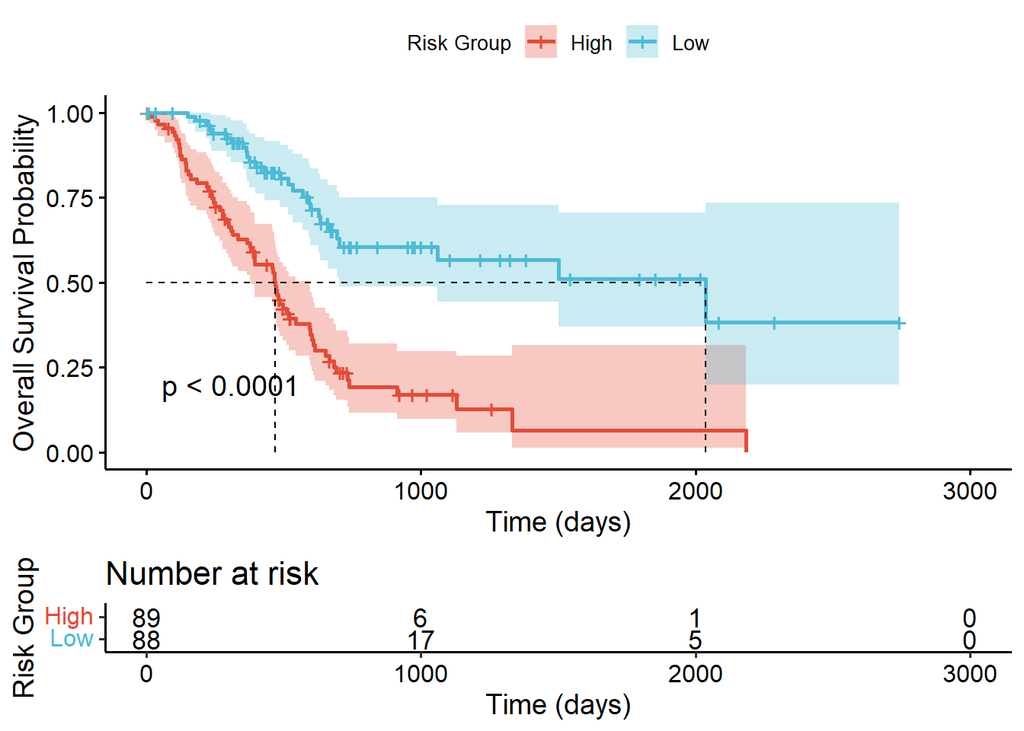

```r
# STEP 16: Kaplan–Meier Plot for Risk Groups

y <- Surv(data_cox$OS_time, data_cox$OS_event)

km_fit <- survfit(y ~ risk_group, data = data_cox)

# Plot KM curve
ggsurvplot(
  km_fit,
  data = data_cox,
  risk.table = TRUE,        # show risk table below plot
  pval = TRUE,              # log-rank p-value
  conf.int = TRUE,          # confidence intervals
  palette = c("#E64B35", "#4DBBD5"), # custom colors
  legend.title = "Risk Group",
  legend.labs = c("High", "Low"),
  xlab = "Time (days)",
  ylab = "Overall Survival Probability",
  surv.median.line = "hv"   # add median survival lines
)
```

## Step 17: Time-Dependent ROC Analysis

```r
# STEP 17: Time-Dependent ROC Analysis

# ROC at 1, 3, and 5 years (365, 1095, 1825 days)
roc_results <- timeROC(
  T = data_cox$OS_time,
  delta = data_cox$OS_event,
  marker = data_cox$risk_score,
  cause = 1,
  times = c(365, 1095, 1825),
  iid = TRUE
)

# Print AUC values
print("Time-dependent ROC AUCs:")
```

```
## [1] "Time-dependent ROC AUCs:"
```

```r
print(roc_results$AUC)
```

```
##     t=365    t=1095    t=1825
## 0.7978453 0.8458006 0.8942202
```

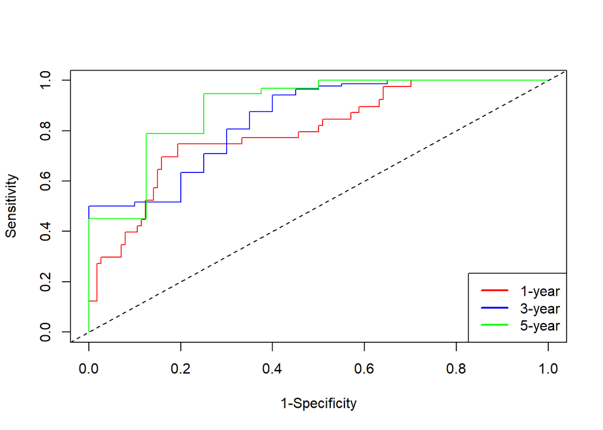

```r
# Plot ROC curves
plot(roc_results, time = 365, col = "red", title = FALSE)
plot(roc_results, time = 1095, col = "blue", add = TRUE)
plot(roc_results, time = 1825, col = "green", add = TRUE)
legend("bottomright", legend = c("1-year", "3-year", "5-year"),
       col = c("red", "blue", "green"), lwd = 2)
```